# CSS Seed Predator

Jenna Loesberg

3/16/2021

Which sites to drop:

- sites where more than 5 seeds were missing from Exclusion dish
- sites where less than 10 or more than 70 seeds taken
- sites where seeds taken are less than 10 different from Exclusion

Dropping sites with more than 5 seeds missing from Exclusion dish

```r
# Selecting exclusion dishes with 5 or less seeds missing, there are 94
exc <- seed %>%
   filter(Treatment == "C")  #101 observations


exc <- exc %>%
  filter(Total_eaten <=5) #94 observations

# get unique ID for those sites:
exc_codes <- exc %>%
  select(GPS_code)
# add back the rest of the data
seed <- semi_join(seed, exc_codes) #seed 3 = without those Exc sites
# BR and A only dishes with seed eaten no. between 10 and 70
BR <- seed %>%
  filter(Treatment == "BR+") %>% #88 dishes
  filter(Total_eaten  %in% (10:70)) #52 dishes

A <- seed %>%
  filter(Treatment == "A+") %>% #90 dishes
  filter(Total_eaten  %in% (10:70)) #5 dishes
ABR <- rbind(BR, A)
# ABR: These are the sites we're keeping.

# do any of these sites have <10 differnece with control?
GPS <- ABR %>%
  select(GPS_code) #these are the sites that we need control numbers for

GPS <- semi_join(exc, GPS) #control sites for each site that meet criteria
ABR <- rbind(GPS, ABR)
ABR2 <- ABR
#one site has a too small seed difference between C and trt:

ABR <- ABR %>%
  filter(GPS_code != "JL_Feb15_S2") %>%
  arrange(GPS_code, Treatment)


# These are the sites that do not have camera data: let's exclude them from the analyses

ABR <- ABR %>%
  filter(GPS_code != "May22_S2") %>%
  filter(GPS_code != "Nov5_S4") %>%
  filter(GPS_code != "Oct10_S1") %>%
  filter(GPS_code != "Sep17_S4") %>%
  filter(GPS_code != "Ap23_S2") %>%
  filter(GPS_code != "Ap23_S4")

#ABR has all of the sites that we're including! Now getting just A and BR
Global_final <- ABR %>%
  filter(Treatment != "C")
```

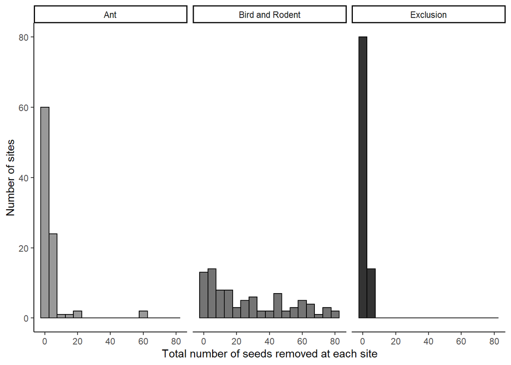

```r
#Changing label names for fact wrap
treatment_names <- c("BR+" = "Bird and Rodent",
                     "A+" = "Ant",
                     "C" = "Exclusion")

seed %>%
  ggplot(aes(x = Total_eaten, fill = Treatment))+
  geom_histogram(binwidth=5, color = "black")+
  facet_wrap(~Treatment, labeller = as_labeller(treatment_names))+
  scale_fill_grey(start=0.6, end=0.2) +
  theme(legend.position = "none")+
  labs(x = "Total number of seeds removed at each site", y = "Number of sites")
```

```r
#ggsave("figures/histogram.png", width = 8, height = 4)

# Histogram of cleaned data:
#ABR2 %>%
  #ggplot(aes(x = Total_eaten, fill=Treatment))+
  #geom_histogram(binwidth=5)+
  #facet_wrap(~Treatment, labeller = as_labeller(treatment_names))+
  #scale_fill_grey()+
  #theme(legend.position = "none")+
  #labs(x = "Total number of seeds removed at end of experiment", y = "Count")
```

creating Manly alpha indices:

```r
Global_final["prey"] <- 20 #starting amount  = 20
Global_final <- Global_final %>%
  mutate(salv.pro = salvia.left/prey, #proportion of starting amount
         enc.pro = encelia_left/prey,
         brom.pro = bromus_left/prey,
         bras.pro = brassica_left/prey)
#add small vlaue to zeros to take log:
Global_final$salv.pro[Global_final$salv.pro == 0] <- 0.001
Global_final$enc.pro[Global_final$enc.pro == 0] <- 0.001
Global_final$brom.pro[Global_final$brom.pro == 0] <- 0.001
Global_final$bras.pro[Global_final$bras.pro == 0] <- 0.001

Global_final <- Global_final %>%
  mutate(salvia = log(salv.pro)/(log(salv.pro)+log(enc.pro)+log(brom.pro)+log(bras.pro)), #manly calc
         encelia = log(enc.pro)/(log(salv.pro)+log(enc.pro)+log(brom.pro)+log(bras.pro)),
         bromus = log(brom.pro)/(log(salv.pro)+log(enc.pro)+log(brom.pro)+log(bras.pro)),
         brassica = log(bras.pro)/(log(salv.pro)+log(enc.pro)+log(brom.pro)+log(bras.pro)))

#here I will split it up into A, BR and global

A_final <- Global_final %>%
  filter(Treatment == "A+")
BR_final <- Global_final %>%
  filter(Treatment == "BR+")
```

This is in wide format, need to switch to long

```r
BR_final <- BR_final %>%
  select(GPS_code, salvia, encelia, bromus, brassica) %>%
  pivot_longer(cols = c(salvia:brassica), names_to = "species", values_to = "index")
A_final <- A_final %>%
  select(GPS_code, salvia, encelia, bromus, brassica) %>%
  pivot_longer(cols = c(salvia:brassica), names_to = "species", values_to = "index")
Global_final <- Global_final %>%
  select(Treatment, GPS_code, salvia, encelia, bromus, brassica) %>%
  pivot_longer(cols = c(salvia:brassica), names_to = "species", values_to = "index")
```

T-tests for each seed species. Are the true means different from 0.25?

```r
bromus <- Global_final %>%
  filter(species == "bromus") %>%
  select(index)
t.test(bromus, mu = 0.25)
```

```
##
##  One Sample t-test
##
## data:  bromus
## t = -2.124, df = 49, p-value = 0.03874
## alternative hypothesis: true mean is not equal to 0.25
## 95 percent confidence interval:
##  0.1214085 0.2464405
## sample estimates:
## mean of x
## 0.1839245
```

```r
brassica <- Global_final %>%
  filter(species == "brassica") %>%
  select(index)
t.test(brassica, mu = 0.25)
```

```
##
##  One Sample t-test
##
## data:  brassica
## t = 5.0737, df = 49, p-value = 6.005e-06
## alternative hypothesis: true mean is not equal to 0.25
## 95 percent confidence interval:
##  0.3560355 0.4951191
## sample estimates:
## mean of x
## 0.4255773
```

```r
salvia <- Global_final %>%
  filter(species == "salvia") %>%
  select(index)
t.test(salvia, mu = 0.25)
```

```
##
##  One Sample t-test
##
## data:  salvia
## t = -0.14028, df = 49, p-value = 0.889
## alternative hypothesis: true mean is not equal to 0.25
## 95 percent confidence interval:
##  0.1943824 0.2983593
## sample estimates:
## mean of x
## 0.2463709
```

```r
encelia <- Global_final %>%
  filter(species == "encelia") %>%
  select(index)
t.test(encelia, mu = 0.25)
```

```
##
##  One Sample t-test
##
## data:  encelia
## t = -5.7254, df = 49, p-value = 6.182e-07
## alternative hypothesis: true mean is not equal to 0.25
## 95 percent confidence interval:
##  0.1069666 0.1812880
## sample estimates:
## mean of x
## 0.1441273
```

Confidence intervals for graph:

```r
BR_sum <- BR_final %>%
  group_by(species) %>%
  summarize(mean = mean(index), sd = sd(index), n = n(), se = sd/sqrt(n))
Global_sum <- Global_final %>%
  group_by(species) %>%
  summarize(mean = mean(index),
            sd = sd(index),
            n = n(),
            se = sd/sqrt(n),
            lower.ci = mean-1.96*sd/sqrt(n),
            upper.ci = mean+1.96*sd/sqrt(n))
A_sum <- A_final %>%
  group_by(species) %>%
  summarize(mean = mean(index), sd = sd(index), n = n(), se = sd/sqrt(n))
Global_sum <- left_join(Global_sum, info, by = "species")
Global_sum$species[Global_sum$species == "brassica"] <- "Brassica"
Global_sum$species[Global_sum$species == "bromus"] <- "Bromus"
Global_sum$species[Global_sum$species == "encelia"] <- "Encelia"
Global_sum$species[Global_sum$species == "salvia"] <- "Salvia"
```

Global plot:

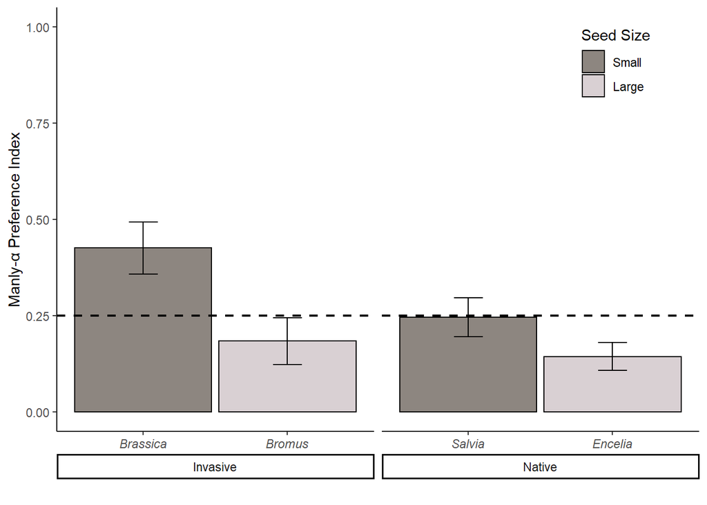

```r
Global_sum %>%
  mutate(species = as.factor(species),
         size = as.factor(size)) %>%
  ggplot(aes(x = factor(species, levels = c("Brassica","Bromus","Salvia", "Encelia")), y = mean))+
  geom_col(aes(fill = size), width = .95, color = "black")+
  #geom_point(data = Global_final, aes(species, index))+
  scale_fill_manual(values=c("#D9D0D3", "#8D8680"), guide = guide_legend(reverse=TRUE))+
  geom_hline(aes(linetype = "Preference Threshold"), yintercept=0.25,linetype="dashed", color = "black", size = .8)+
  #scale_linetype_manual(name = "", values = c(1, 1), guide = guide_legend(override.aes = "black"))+
  geom_errorbar(aes(ymin = lower.ci, ymax = upper.ci), width = 0.2)+
  expand_limits(y = c(0, 1))+
  labs(y= "Manly-\u03B1 Preference Index", x = "", fill = "Seed Size")+
  facet_grid(.~origin, scales = "free", switch = "x", space = "free")+
   theme(strip.placement = "outside",
         legend.position = c(0.87, 0.87),
         axis.text.x = element_text(face = "italic"))
```

```r
#ggsave("figures/GlobalManly.png", width = 7, height = 5)

# n = 50
```

Add in the granivore species information from the camera:

```r
site_species <- species %>%
  select(c(Run, GPS_code, Site, Sp_ate))

site_species <- left_join(Global_final, site_species, by = "GPS_code")
site_species$Sp_ate <- ifelse(site_species$Treatment == "A+", "ant", site_species$Sp_ate)
```

species specific plot:

```r
labels <- c(ant = "Ant", CA_Towee = "California Towhee", GS = "Ground Squirrel", mixed_bird = "Multiple Birds", mixed_mammal = "Multiple Mammals", multipred = "Multiple Guilds", none = "No Visits", scrub_jay = "Scrub Jay", WC_sparrow = "WC Sparrow", woodrat = "Woodrat")

site_species <- site_species %>%
  filter(Sp_ate != "none") %>%
  mutate(Sp_ate = as.factor(Sp_ate),
         species = as.factor(species),
         species = factor(species, levels = c("brassica","bromus","salvia", "encelia")),
         Sp_ate = factor(Sp_ate, levels = c("mixed_bird", "CA_Towee", "scrub_jay", "WC_sparrow", "ant", "multipred", "mixed_mammal", "woodrat", "GS")))

species_stat <- site_species %>%
  group_by(species, Sp_ate) %>%
  summarize(mean = mean(index)) %>%
  filter(Sp_ate == "mixed_bird"| Sp_ate =="CA_Towee"|Sp_ate =="ant"| Sp_ate =="multipred" )
```

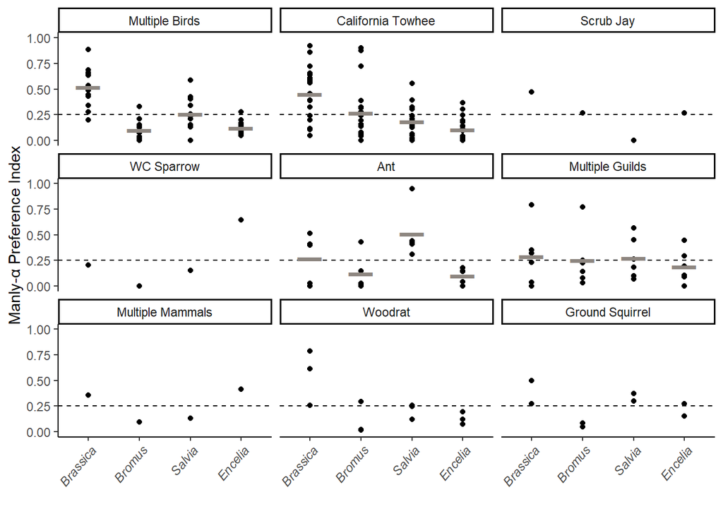

```r
site_species %>%
  group_by(species) %>%
  ggplot(aes(species, index))+
  geom_point()+
  geom_hline(yintercept=0.25,linetype="dashed", color = "black", size = .5)+
  expand_limits(y = c(0, 1))+
  facet_wrap(~Sp_ate, labeller = labeller(Sp_ate = labels), ncol = 3)+
  labs(y= "Manly-\u03B1 Preference Index", x = "")+
  theme(axis.text.x=element_text(angle=50, hjust=1)) +
  geom_point(data = species_stat, aes(y = mean, x = species), shape = 95, size = 10, color = "#8D8680")+
  scale_x_discrete(labels = c("Brassica","Bromus","Salvia", "Encelia"))+ #just changes names
  theme(axis.text.x = element_text(face = "italic"))
```

```r
#ggsave("figures/specices_preference_1.png", width = 7, height = 6 )
```

One sample t-tests for all of those means:

- Multiple birds:

```r
mult_birds_seeds <- site_species %>%
  filter(Sp_ate == "mixed_bird")

MBbird_bromus <- mult_birds_seeds %>%
  filter(species == "bromus") %>%
  select(index)
t.test(MBbird_bromus, mu = 0.25)
```

```
##
##  One Sample t-test
##
## data:  MBbird_bromus
## t = -5.2284, df = 11, p-value = 0.0002818
## alternative hypothesis: true mean is not equal to 0.25
## 95 percent confidence interval:
##  0.03816417 0.16367926
## sample estimates:
## mean of x
## 0.1009217
```

```r
MBbird_brassica <- mult_birds_seeds %>%
  filter(species == "brassica") %>%
  select(index)
t.test(MBbird_brassica, mu = 0.25)
```

```
##
##  One Sample t-test
##
## data:  MBbird_brassica
## t = 4.7584, df = 11, p-value = 0.0005916
## alternative hypothesis: true mean is not equal to 0.25
## 95 percent confidence interval:
##  0.3941274 0.6422041
## sample estimates:
## mean of x
## 0.5181657
```

```r
MBbird_salvia <- mult_birds_seeds %>%
  filter(species == "salvia") %>%
  select(index)
t.test(MBbird_salvia, mu = 0.25)
```

```
##
##  One Sample t-test
##
## data:  MBbird_salvia
## t = 0.18705, df = 11, p-value = 0.855
## alternative hypothesis: true mean is not equal to 0.25
## 95 percent confidence interval:
##  0.1584539 0.3585517
## sample estimates:
## mean of x
## 0.2585028
```

```r
MBbird_encelia <- mult_birds_seeds %>%
  filter(species == "encelia") %>%
  select(index)
t.test(MBbird_encelia, mu = 0.25)
```

```
##
##  One Sample t-test
##
## data:  MBbird_encelia
## t = -6.5473, df = 11, p-value = 4.151e-05
## alternative hypothesis: true mean is not equal to 0.25
## 95 percent confidence interval:
##  0.07951814 0.16530134
## sample estimates:
## mean of x
## 0.1224097
```

- towhee:

```r
towhee_seeds <- site_species %>%
  filter(Sp_ate == "CA_Towee")

towhee_bromus <- towhee_seeds %>%
  filter(species == "bromus") %>%
  select(index)
t.test(towhee_bromus, mu = 0.25)
```

```
##
##  One Sample t-test
##
## data:  towhee_bromus
## t = 0.24616, df = 18, p-value = 0.8083
## alternative hypothesis: true mean is not equal to 0.25
## 95 percent confidence interval:
##  0.1323390 0.3988928
## sample estimates:
## mean of x
## 0.2656159
```

```r
towhee_brassica <- towhee_seeds %>%
  filter(species == "brassica") %>%
  select(index)
t.test(towhee_brassica, mu = 0.25)
```

```
##
##  One Sample t-test
##
## data:  towhee_brassica
## t = 3.2774, df = 18, p-value = 0.004185
## alternative hypothesis: true mean is not equal to 0.25
## 95 percent confidence interval:
##  0.3212697 0.5758160
## sample estimates:
## mean of x
## 0.4485428
```

```r
towhee_salvia <- towhee_seeds %>%
  filter(species == "salvia") %>%
  select(index)
t.test(towhee_salvia, mu = 0.25)
```

```
##
##  One Sample t-test
##
## data:  towhee_salvia
## t = -2.0414, df = 18, p-value = 0.05615
## alternative hypothesis: true mean is not equal to 0.25
## 95 percent confidence interval:
##  0.1127865 0.2519708
## sample estimates:
## mean of x
## 0.1823786
```

```r
towhee_encelia <- towhee_seeds %>%
  filter(species == "encelia") %>%
  select(index)
t.test(towhee_encelia, mu = 0.25)
```

```
##
##  One Sample t-test
##
## data:  towhee_encelia
## t = -5.7936, df = 18, p-value = 1.725e-05
## alternative hypothesis: true mean is not equal to 0.25
## 95 percent confidence interval:
##  0.0503241 0.1566012
## sample estimates:
## mean of x
## 0.1034626
```

- ant:

```r
ant_seeds <- site_species %>%
  filter(Sp_ate == "ant")

ant_bromus <- ant_seeds %>%
  filter(species == "bromus") %>%
  select(index)
t.test(ant_bromus, mu = 0.25)
```

```
##
##  One Sample t-test
##
## data:  ant_bromus
## t = -1.5835, df = 4, p-value = 0.1885
## alternative hypothesis: true mean is not equal to 0.25
## 95 percent confidence interval:
##  -0.1043772  0.3469653
## sample estimates:
## mean of x
## 0.1212941
```

```r
ant_brassica <- ant_seeds %>%
  filter(species == "brassica") %>%
  select(index)
t.test(ant_brassica, mu = 0.25)
```

```
##
##  One Sample t-test
##
## data:  ant_brassica
## t = 0.18353, df = 4, p-value = 0.8633
## alternative hypothesis: true mean is not equal to 0.25
## 95 percent confidence interval:
##  -0.02716817  0.56640434
## sample estimates:
## mean of x
## 0.2696181
```

```r
ant_salvia <- ant_seeds %>%
  filter(species == "salvia") %>%
  select(index)
t.test(ant_salvia, mu = 0.25)
```

```
##
##  One Sample t-test
##
## data:  ant_salvia
## t = 2.2786, df = 4, p-value = 0.08492
## alternative hypothesis: true mean is not equal to 0.25
## 95 percent confidence interval:
##  0.1938395 0.8202618
## sample estimates:
## mean of x
## 0.5070507
```

```r
ant_encelia <- ant_seeds %>%
  filter(species == "encelia") %>%
  select(index)
t.test(ant_encelia, mu = 0.25)
```

```
##
##  One Sample t-test
##
## data:  ant_encelia
## t = -4.3643, df = 4, p-value = 0.01202
## alternative hypothesis: true mean is not equal to 0.25
## 95 percent confidence interval:
##  0.007908171 0.196166167
## sample estimates:
## mean of x
## 0.1020372
```

- Multiple taxa:

```r
mult_taxa_seeds <- site_species %>%
  filter(Sp_ate == "multipred")

mult_taxa_bromus <- mult_taxa_seeds %>%
  filter(species == "bromus") %>%
  select(index)
t.test(mult_taxa_bromus, mu = 0.25)
```

```
##
##  One Sample t-test
##
## data:  mult_taxa_bromus
## t = 0.0038641, df = 5, p-value = 0.9971
## alternative hypothesis: true mean is not equal to 0.25
## 95 percent confidence interval:
##  -0.03014113  0.53098463
## sample estimates:
## mean of x
## 0.2504217
```

```r
mult_taxa_brassica <- mult_taxa_seeds %>%
  filter(species == "brassica") %>%
  select(index)
t.test(mult_taxa_brassica, mu = 0.25)
```

```
##
##  One Sample t-test
##
## data:  mult_taxa_brassica
## t = 0.33556, df = 5, p-value = 0.7508
## alternative hypothesis: true mean is not equal to 0.25
## 95 percent confidence interval:
##  -0.01083297  0.58915510
## sample estimates:
## mean of x
## 0.2891611
```

```r
mult_taxa_salvia <- mult_taxa_seeds %>%
  filter(species == "salvia") %>%
  select(index)
t.test(mult_taxa_salvia, mu = 0.25)
```

```
##
##  One Sample t-test
##
## data:  mult_taxa_salvia
## t = 0.28074, df = 5, p-value = 0.7902
## alternative hypothesis: true mean is not equal to 0.25
## 95 percent confidence interval:
##  0.06467411 0.48076958
## sample estimates:
## mean of x
## 0.2727218
```

```r
mult_taxa_encelia <- mult_taxa_seeds %>%
  filter(species == "encelia") %>%
  select(index)
t.test(mult_taxa_encelia, mu = 0.25)
```

```
##
##  One Sample t-test
##
## data:  mult_taxa_encelia
## t = -0.94961, df = 5, p-value = 0.3859
## alternative hypothesis: true mean is not equal to 0.25
## 95 percent confidence interval:
##  0.01903776 0.35635292
## sample estimates:
## mean of x
## 0.1876953
```

Now onto the community graph…

```r
# take out non-granivore species
species2 <- species[-c(5, 18, 21, 26, 34, 35, 36)]
```

Changing the dataframe into a useable format:

```r
species2 <- species
species2[species2 == 0] <- NA
#species_n <- species2 %>%
 # select(-c(Site, Days_Out)) %>%
#  summarize_all(n, na.rm = TRUE)
species3 <- species2 %>%
  summarize_if(is.numeric, sum, na.rm=TRUE) # add up all of the observations

species3 <- species3 %>%
  pivot_longer(cols = -c(Site, Days_Out), values_to = "number" , names_to = c("species", "type"), names_sep = "_")
species3[is.na(species3)] <- 0

species4 <- species3 %>%
  pivot_wider(names_from = "type", values_from = "number") %>%
  select(-c(Site, Days_Out))
species4[is.na(species4)] <- 0
species4 <- species4%>%
  group_by(species) %>%
  mutate(ratio = Eat/(Visit+Eat))
#write.csv(species4, "species2.csv", row.names = F)
#write.csv(species2, "species_persite.csv", row.names = F)

#present <- species %>%
  #select(-c(Site, Days_Out, Run, Sp_ate))
  #pivot_longer(cols = -c(Site, Days_Out), values_to = "number" , names_to = c("species", "type"), names_sep = "_") %>%
 # pivot_wider(names_from = "type", values_from = "number")
```

Graph that we won’t use:

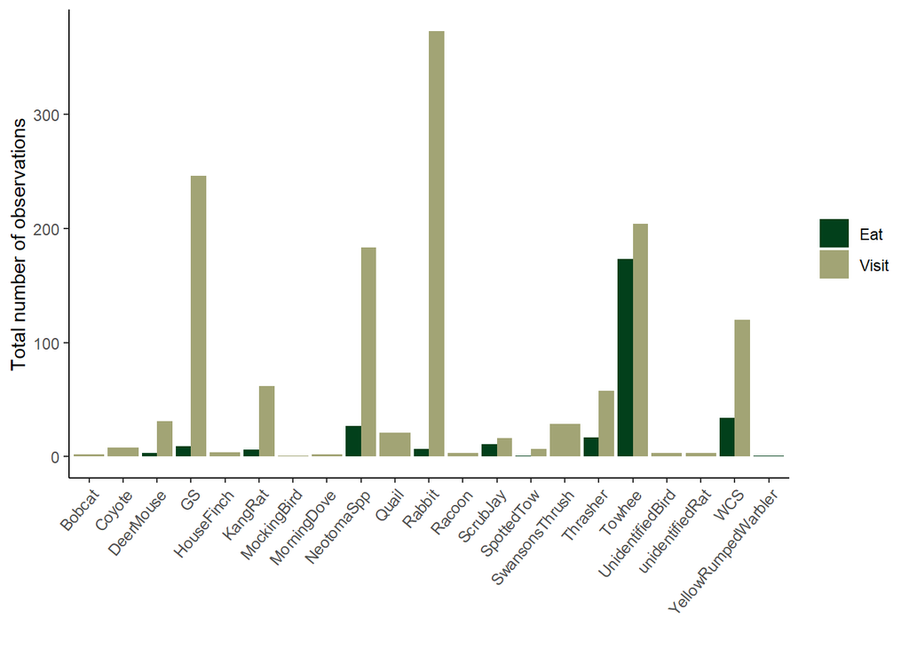

```r
species3 %>%
  group_by(species, type) %>%
  ggplot(aes(species, number, fill = type))+
  geom_bar(stat = "identity", position = "dodge")+
  theme(axis.text.x=element_text(angle=50, hjust=1),legend.title = element_blank())+
  labs(x= "", y = "Total number of observations", main = "")+
  scale_fill_manual(values=cav[2:3])
```

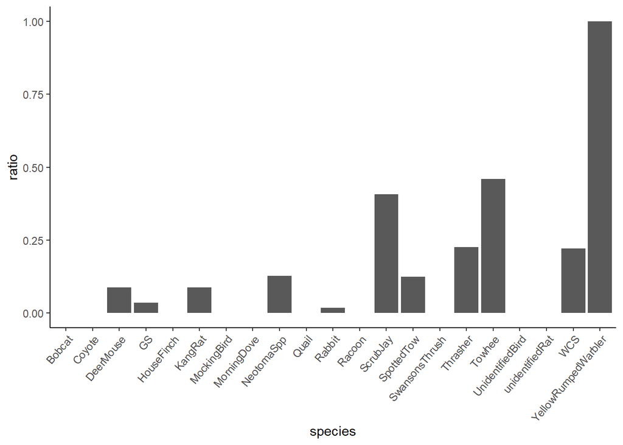

```r
#ggsave("visits_Aug31.jpeg", width = 10, height = 7)

species4 %>%
  group_by(species) %>%
  ggplot(aes(species, ratio))+
  geom_bar(stat = "identity", position = "dodge")+
  theme(axis.text.x=element_text(angle=50, hjust=1))
```

Let’s make a table instead using new gt package

Need number of sites each each was observed at:

```r
table <- read.csv("C:/Users/Jenna/Dropbox/Jenna/seed predator/CSS_SeedPredator/species_table.csv")
```

```r
table <- table %>% arrange(taxa, SciName) %>% select(-taxa)
# make all column integers so they are centered in table:
#table$Eat <- as.numeric(table$Eat)
#table$Visit <- as.numeric(table$Visit)
#table$SitesPresent <- as.numeric(table$SitesPresent)

tbl <- gt(data = table)
tbl
```

| SciName | CommonName | Eat | Visit | ratio | SitesPresent |
| --- | --- | --- | --- | --- | --- |
| Aphelocoma californica | Scrub Jay | 11 | 16 | 0.40740741 | 15 |
| Callipepla californica | Quail | 0 | 21 | 0.00000000 | 9 |
| Catharus ustulatus | Swansons Thrush | 0 | 29 | 0.00000000 | 3 |
| Haemorhous mexicanus | House Finch | 0 | 4 | 0.00000000 | 2 |
| Melozone crissalis | California Towhee | 173 | 204 | 0.45888594 | 68 |
| Mimus polyglottos | Mocking Bird | 0 | 1 | 0.00000000 | 1 |
| Pipilo maculatus | Spotted Towhee | 1 | 7 | 0.12500000 | 7 |
| Setophaga coronata | Yellow Rumped Warbler | 1 | 0 | 1.00000000 | 1 |
| Toxostoma redivivum | California Thrasher | 17 | 58 | 0.22666667 | 34 |
| Zenaida macroura | Morning Dove | 0 | 2 | 0.00000000 | 2 |
| Zonotrichia leucophrys | White Crowned Sparrow | 34 | 120 | 0.22077922 | 22 |
| NA | Unidentified Bird | 0 | 3 | 0.00000000 | 3 |
| Sylivagus audubonii | Desert Cottontail | 7 | 373 | 0.01842105 | 66 |
| Dipodomys californicus | Kangaroo Rat | 6 | 62 | 0.08823529 | 17 |
| Neotoma spp. | Wood Rat | 27 | 183 | 0.12857143 | 29 |
| Otospermophilus beecheyi | Ground Squirrel | 9 | 246 | 0.03529412 | 9 |
| Peromyscus spp. | Deer Mouse | 3 | 31 | 0.08823529 | 14 |
| NA | Unidentified Rat | 0 | 3 | 0.00000000 | 2 |

```r
tbl1 <- tbl %>%
  tab_row_group(group = "Bird", rows = 1:12) %>%
  tab_row_group(group = "Rodent", rows = 14:18) %>%
  tab_row_group(group = "Lagomorph", rows = 13) %>%
  row_group_order(groups = c("Bird", "Rodent", "Lagomorph")) %>%
  tab_stubhead(label = "Group") %>%
  tab_spanner(label = "Type of Observtion", columns = vars(Eat, Visit)) %>%
  fmt_number(column = vars(ratio), decimals = 2) %>%
  cols_label(SciName = "Scientific Name", CommonName = "Common Name", Eat = "Seed Predation", ratio = "Ratio of predation events to total events", SitesPresent = "Sites with at least one observation") %>%
  tab_style(style = cell_text(style = "italic"), locations = cells_body(columns = vars(SciName))) %>%
  fmt_missing(columns = 1:2, missing_text = "---") %>%
  cols_align(align = "center") %>%
  cols_width(everything() ~ px(90)) %>%
  cols_width(ends_with("Name") ~ px(150))

tbl1
```

[output not shown]

```r
#webshot::install_phantomjs()
#tbl1 %>% gtsave("figures/fig3_Feb18.png")
```